# Lab 3: Airbnbs in Edinburgh

Exploring numerical data

The main goal of this lab is to give you practice with summarizing distributions. **You will be uploading the `.Rmd` and `.html` files as before.**

**Resources** Please consult the slidedecks from weeks 3 and 4 on the for help with the various functions on this lab. I am also assuming that you are familiar with the lessons contained in the interactive tutorials and that were introduced in Week 4.

**Learning Objectives**

- Practice making plots using `ggplot`
- Summarizing distributions visually and numerically

Once upon a time, people traveled all over the world, and some stayed in hotels and others chose to stay in other people’s houses that they booked through Airbnb. Recent developments in Edinburgh regarding the growth of Airbnb and its impact on the housing market means a better understanding of the Airbnb listings is needed. Using data provided by Airbnb, we can explore how Airbnb availability and prices vary by neighbourhood.

## Getting started

Access JupyterHub from CANVAS and create a new lab report as we have done before. Be sure to personalize the header with the title of the lab and also add your name.

### Packages

In this assignment we will work with three packages: **dsbox** which contains the dataset we will be using and of course **tidyverse**. We will also use **ggridges** to make density ridge plots. Edit the `setup` code chunk of the lab template to load the following packages. Also run the chunk to load the packages in your working environment by clicking the green Play button.

```r
library(tidyverse)
library(dsbox)
library(ggridges)
```

## The Data

The data can be found in the **dsbox** package, and it’s called `edibnb`. You can **load** the data frame into your interactive environment (i.e., the Console) and take a look at the contents in the spreadsheet viewer.

```r
data(edibnb)  #type in Console
```

To find out more about the data frame, type the following in your Console.

```r
?edibnb #type in Console
```

1. What does each row in the data set represent? Write a sentence with the answer.
2. Create a histogram of the distribution of Airbnb listing prices (nightly rates) in Edinburgh. Describe the shape of the distribution. Write your answer in a complete sentence.

   *Hint* Choose your binwidth intentionally to create a histogram that is not too jagged and not too flat. Don’t forget the rule of thumb for the **number of bins** is `log2(n)` as a starting point.

In the next exercise, you will be calculating numerical summaries for the variable `price`. In particular, you will be reporting a typical daily price for a rental (called a measure of center) and also give some idea of the variability in the daily prices.

As discussed in the tutorial “Summarizing numerical data” which can be found in the Tutorial pane (`stat311tutorials::gapminder`), we report the mean and standard deviation when summarizing symmetric distributions. Skewed distributions should be summarized by calculating the median and 25th and 75th percentiles.

As an example, the following code chunk shows you how to calculate these numbers for the variable `lifeExp` from the `gapminder` dataframe. Feel free to type `?` followed by the function name - for example `?quantile` - in the Console to learn more about what the function does and its syntax. You may need to specify the `na.rm` argument if there are missing values.

```r
#You do not need to type this; just read it

gapminder %>%
  summarise( mean_exp = mean(lifeExp),            #mean
             sd_exp = sd(lifeExp),                #standard deviation
             median_exp = median(lifeExp),        #median
             q25 = quantile(lifeExp, p = 0.25),   #25th percentile
             q75 = quantile(lifeExp, p = 0.75))
```

3. Repurpose the code shown above to calculate the summary measures for `price` in the Airbnb dataset. Be sure to show the code, output and then write a couple of sentences stating the relevant numbers in context.

   **Hint** If the distribution is symmetric, report only the mean and standard deviation. For skewed distributions report only the 25th percentile, median and 75th percentile. See the footnote<sup>1</sup> for advice on how to print the £ symbol within your text.

Next, let us examine the prices by `neighbourhood`. Please note the English spelling of neighborhood!

4. Write code to recreate the following side-by-side boxplots to display the distribution of Airbnb prices by neighbourhood. Be sure to (please see slidedeck1 from week 4 if you need help)
   - filter the data to remove any listings where the `neighbourhood` is missing (NA) before you make the boxplot
   - remove axis ticks and text on the $y$ axis
   - include a `labs` layer to give meaningful titles and labels
   - show your code and output.

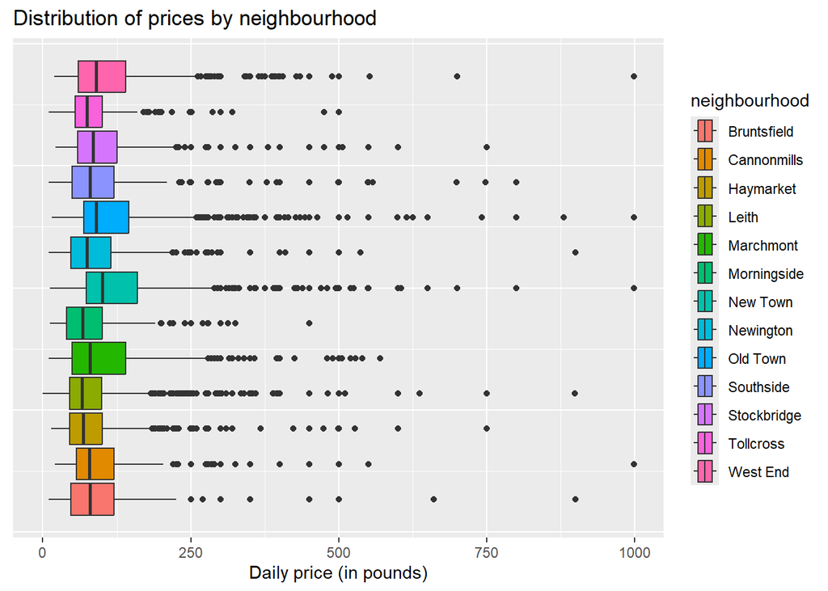

5. Write code to print the following output listing neighborhoods in descending order of median price. Be sure to match the output exactly.

   ```
   ## # A tibble: 13 × 2
   ##    neighbourhood median_pr
   ##    <chr>             <dbl>
   ##  1 New Town            100
   ##  2 Old Town             90
   ##  3 West End             90
   ##  4 Stockbridge          85
   ##  5 Bruntsfield          80
   ##  6 Marchmont            80
   ##  7 Southside            80
   ##  8 Cannonmills          79
   ##  9 Newington            75
   ## 10 Tollcross            75
   ## 11 Haymarket            68
   ## 12 Morningside          67
   ## 13 Leith                66
   ```

6. Write code to recreate the following density ridge plot to compare the distribution of review scores (`review_scores_rating`) for the top four neighbourhoods from exercise 5. Be sure to show code and output. Then include a brief interpretation of how Airbnb guests rate properties in general.

   Hint: you may want to first create a new dataframe (call it edibnb_top4) with the listings corresponding to the top four neighborhoods. Then make your plot using this dataframe.

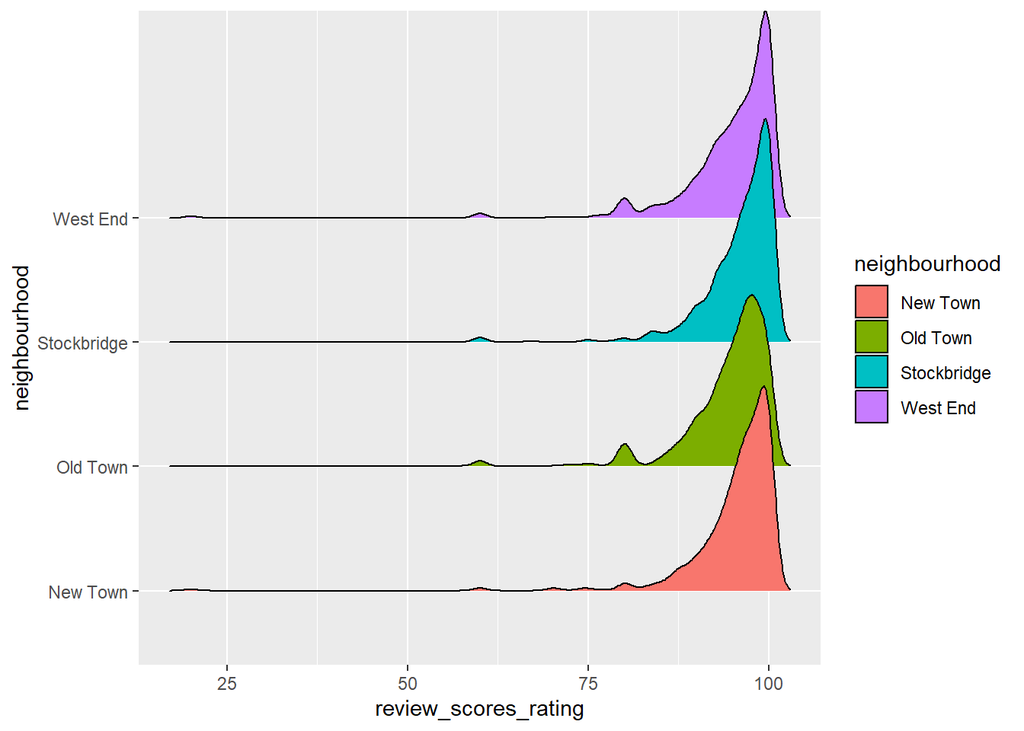

You’re done with the data analysis exercises, but we’d like you to do two more things.

**Resize your figures**: Click on the gear icon on top of the R Markdown document, and select “Output Options…” in the drop down menu. In the pop up dialogue box go to the Figures tab and change the height and width of the figures, and hit OK when done. Then, knit your document and see how you like the new sizes. Change and knit again and again until you’re happy with the figure sizes. Note that these values get saved in the YAML or header of your lab report!

You can also use different figure sizes for different figures. To do so click on the gear icon within the chunk where you want to make a change. Changing the figure sizes added new options to these chunks: fig.width and fig.height. You can change them by defining different values directly in your R Markdown document as well.

**Now, change the look of your report:**

Once again click on the gear icon in on top of the R Markdown document, and select “Output Options…” in the drop down menu. In the General tab of the pop up dialogue box try out different Syntax highlighting and theme options. Hit OK and knit your document to see how it looks. Play around with these until you’re happy with the look.

## Conclusion

Congratulations! This lab marks a significant shift in what you are being asked to do. I hope you are proud of how far you have already come! This concludes Lab 3. Be sure to upload both the `.Rmd` and `.html`.

## Acknowledgments

This lab is from [Data Science in a Box](https://datasciencebox.org) and shared under a Creative Commons Attribution Share-Alike 4.0 International.

<sup>1. Note: the prices are in GBP - the short form of British pound sterling. You do not need to make the pound symbol but if you want to, try typing `&pound;` before the number. For example `&pound;50` will produce £50</sup>